# Html_Spotify_Premium_Duo

## Load data

```python
import pandas as pd
import numpy as np

# Load the dataframes from csv files
duo_user_activity = pd.read_csv("https://storage.googleapis.com/datalynn-datasets/interview-challenge/entertainment-and-media/Spotify_Premium_Duo/duo_user_activity.csv")
song_data = pd.read_csv("https://storage.googleapis.com/datalynn-datasets/interview-challenge/entertainment-and-media/Spotify_Premium_Duo/song_data.csv")
```

## **Question 1**:

**(Data Manipulation & Cleaning)** Given the `DuoUserActivity` and `SongData` tables, can you create a new dataframe that consolidates the top 5 genres preferred by Duo users? Use the total listen time for each genre as the determining factor. Also, create a new column which indicates the average revenue generated from these top genres.

### **Problem Solving Ideas & Tips**:

1. **Joining Tables**: The first task involves joining `DuoUserActivity` and `SongData` based on the `PlaylistID`.
2. **Filtering Duo Users**: Once the tables are joined, we need to filter out the data only for Duo users.
3. **Aggregating Data**: Next, aggregate the data based on the genre and calculate the sum of listen time.
4. **Sorting and Selecting Top 5**: Sort the aggregated data based on total listen time to determine the top 5 genres.
5. **Calculate Average Revenue**: For each of these top genres, calculate the average revenue from the users who listened to them.

### **SQL Solution**:

To work with SQL solutions, the pandas dataframes need to be converted to SQL tables. I'll show this process using `sqlite3`.

```python
import sqlite3

# Create an in-memory database for SQLite
conn = sqlite3.connect(':memory:')

# Convert pandas dataframes to SQL tables
duo_user_activity.to_sql('DuoUserActivity', conn, index=False)
song_data.to_sql('SongData', conn, index=False)

# SQL solution
query = """
WITH DuoGenreListen AS (
    SELECT
        d.UserID,
        s.Genre,
        d.ListenTime,
        d.Revenue
    FROM DuoUserActivity d
    JOIN SongData s ON d.PlaylistID = s.PlaylistID
    WHERE d.PremiumType = 'Duo'
)
, GenreAggregation AS (
    SELECT
        Genre,
        SUM(ListenTime) as TotalListenTime,
        AVG(Revenue) as AvgRevenue
    FROM DuoGenreListen
    GROUP BY Genre
    ORDER BY TotalListenTime DESC
    LIMIT 5
)
SELECT * FROM GenreAggregation;
"""

result_sql = pd.read_sql_query(query, conn)
print(result_sql)
```

```
        Genre  TotalListenTime  AvgRevenue
0       Blues          1298.32        22.0
1  Electronic          1123.29        22.0
2      HipHop          1049.02        22.0
3      Reggae           906.57        22.0
4         R&B           896.24        22.0
```

## **Question 2**:

**(Probability and Statistics)** Based on the uniform distribution of song durations within the `SongData` table, if you were to pick 100 random songs, estimate the probability that their average duration is more than 4 minutes?

### **Problem Solving Ideas & Tips**:

1. **Sampling & Calculating Average**: To answer this question, one common method is to use Monte Carlo simulation. That is, we could perform many rounds of randomly selecting 100 songs, and then calculate the proportion of those samples that have an average duration greater than 4 minutes.
2. **Central Limit Theorem (CLT)**: Due to CLT, the average of samples from any distribution will tend to follow a normal distribution. If song durations follow a uniform distribution, we can compute the mean and variance of that distribution, and then derive the distribution of the average of 100 songs.

### **Solution**:

To get necessary metrics (mean and variance) from the SongData table:

```python
mean_duration = song_data['Duration'].mean()
variance_duration = song_data['Duration'].var()
print(mean_duration)
print(variance_duration)
```

```
3.988124
0.2509839574154831
```

Given the mean and variance of the uniform distribution, the mean of the average of 100 songs is the same as the mean of the distribution, and the variance is the variance of the distribution divided by 100 (because we're taking an average).

```python
import scipy.stats as stats

# Parameters for the average of 100 songs
mean_avg = mean_duration
variance_avg = variance_duration / 100
stddev_avg = variance_avg**0.5

# Probability that average duration of 100 songs is more than 4 minutes
probability = 1 - stats.norm.cdf(4, mean_avg, stddev_avg)
print(f"Probability that average duration of 100 songs is more than 4 minutes: {probability:.4f}")
```

```
Probability that average duration of 100 songs is more than 4 minutes: 0.4063
```

## **Question 3:**

**(Machine Learning & Modeling)** Imagine the Premium Duo team is interested in launching a recommendation system for Duo users, leveraging the listening history. Use the `DuoUserActivity` and `SongData` tables to predict the next possible genre a user might want to explore. Please specify which features would be critical for this prediction, and which machine learning model would be suitable for this kind of prediction.

**Problem Solving Ideas and Tips:**

1. **User Listening History**: We need to consider the history of genres each user has listened to. This can be obtained by joining `DuoUserActivity` with `SongData` based on `PlaylistID`.
2. **Feature Creation**:
   - **User-specific**: How many times has the user listened to each genre? What's the average duration they spend on each genre? What's the most recent genre they've listened to? This can hint at a user's evolving music taste.
   - **Song-specific**: Aggregate features such as how popular a song is, how many users have it in their playlist, etc. might be useful.
   - **Timestamp**: If we had timestamps of when songs were played, we could also create temporal features like listening habits (morning vs. night), weekdays vs. weekends, etc.
3. **Model Choice**:
   - Given it's a multi-class classification problem, algorithms like Decision Trees, Random Forests, Gradient Boosted Trees, or Neural Networks could be a good choice.
   - Collaborative filtering techniques or matrix factorization (like Singular Value Decomposition or SVD) are widely used for recommendation tasks.
4. **Evaluation**: We'd need to set aside a portion of our data to test the effectiveness of our model. Accuracy could be one metric, but given that it's a recommendation system, metrics like precision@k or recall@k might be more relevant.

**Solution**:

```python
import pandas as pd
from sklearn.ensemble import RandomForestClassifier
from sklearn.preprocessing import LabelEncoder
from sklearn.model_selection import train_test_split
from sklearn.metrics import classification_report

# Join DuoUserActivity and SongData
merged_data = duo_user_activity.merge(song_data, on='PlaylistID', how='left')

# Create User-specific features: Count of each genre listened by a user
user_genre_counts = merged_data.groupby(['UserID', 'Genre']).size().unstack().fillna(0)
user_genre_counts.reset_index(inplace=True)

# Assuming the next genre the user listens to is our target (this is just a synthetic creation for demonstration)
genres = ['Pop', 'Rock', 'Jazz', 'Classical', 'HipHop', 'Country', 'Blues', 'Electronic', 'Reggae', 'R&B']
user_genre_counts['next_genre'] = user_genre_counts[genres].idxmax(axis=1)
y = user_genre_counts['next_genre']

# Drop non-feature columns
X = user_genre_counts.drop(columns=['UserID', 'next_genre'])

# Train a Random Forest Classifier
X_train, X_test, y_train, y_test = train_test_split(X, y, test_size=0.2, random_state=42)
clf = RandomForestClassifier(n_estimators=100)
clf.fit(X_train, y_train)

# Predict and evaluate
y_pred = clf.predict(X_test)
print(classification_report(y_test, y_pred))
```

```
              precision    recall  f1-score   support

       Blues       0.95      1.00      0.98        21
   Classical       1.00      1.00      1.00        18
     Country       1.00      1.00      1.00        13
  Electronic       0.89      0.80      0.84        10
      HipHop       1.00      0.95      0.98        22
        Jazz       0.97      1.00      0.98        28
         Pop       0.89      1.00      0.94        16
         R&B       1.00      1.00      1.00        10
      Reggae       1.00      0.86      0.92        14
        Rock       1.00      1.00      1.00        21

    accuracy                           0.97       173
   macro avg       0.97      0.96      0.96       173
weighted avg       0.97      0.97      0.97       173
```

## **Question 4:**

**(Product Design & Analytics)** The Duo product marketing team wants to understand the attributes that make a shared playlist successful. Considering the `DuoUserActivity` table, if a playlist has a higher song count and longer listen time, how would you assess the correlation between these metrics and revenue generation? Additionally, if there were to be a decline in listen time, how would you advise the product team to modify their playlist curation approach?

**Problem Solving Ideas and Tips:**

1. **Correlation**: It's crucial to understand the correlation between different metrics. A positive correlation indicates that as one metric increases, the other does too. A negative correlation indicates the opposite.
2. **Visualization**: Visualization tools like scatter plots can provide a visual insight into relationships between metrics.
3. **Cause vs. Correlation**: It's essential to differentiate between cause and correlation. A correlation between two metrics doesn't imply that one causes the other.
4. **Qualitative Insights**: If there's a decline in listen time, consider conducting surveys or interviews with users to understand the reasons behind it.
5. **Iterative Testing**: Introduce changes to playlist curation incrementally and gauge user response to these changes.

**Solution**:

1. **Correlation between Song Count, Listen Time, and Revenue**:

```
            SongCount  ListenTime   Revenue
SongCount    1.000000    0.964004  0.002517
ListenTime   0.964004    1.000000 -0.003200
Revenue      0.002517   -0.003200  1.000000
```

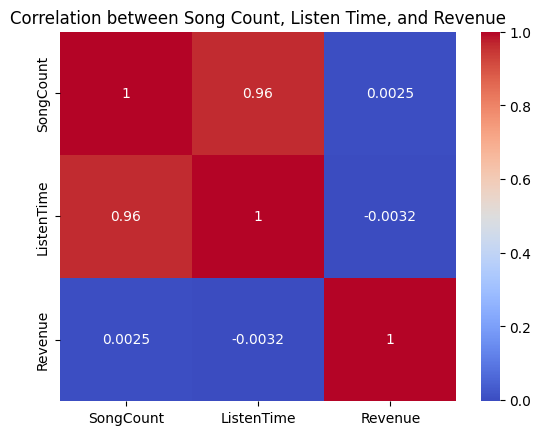

```python
import pandas as pd
import matplotlib.pyplot as plt
import seaborn as sns

# Calculate correlation
correlation_matrix = duo_user_activity[['SongCount', 'ListenTime', 'Revenue']].corr()
print(correlation_matrix)

# Visualize with a heatmap
sns.heatmap(correlation_matrix, annot=True, cmap='coolwarm')
plt.title("Correlation between Song Count, Listen Time, and Revenue")
plt.show()
```

Interpretation: A high positive correlation value (close to 1) between two metrics indicates that when one increases, the other tends to increase as well. Conversely, a high negative correlation (close to -1) indicates that when one metric increases, the other tends to decrease.

2. **Advice for Decline in Listen Time**:

If there's a decline in listen time:

- **Survey Users**: Use user feedback tools to understand why users might be listening less. Perhaps the song recommendations aren't as relevant, or maybe there are technical issues like songs not loading quickly enough.
- **Algorithm Refinement**: Modify the playlist curation algorithm to prioritize songs/artists that have high engagement metrics or introduce more diversity into the playlist to cater to varying tastes.
- **Feature Additions**: Consider introducing features like user-created public playlists, where users can explore playlists curated by other users.
- **Collaboration with Artists**: Partner with popular artists for exclusive releases or early access to songs for Duo users. This can incentivize users to spend more time listening.
- **Education**: Educate users about the features and benefits of the Duo premium, possibly introducing features that allow more personalization or interactivity with the playlists.

Always remember to conduct A/B tests when implementing new features or changes to understand their impact on user behavior better.